# Boston crime analysis for Head of Police

# General overview

| NAME | NB_INCIDENTS | NB_INCIDENTS_OVER_POPULATION | MOST_FREQUENT_OFFENSE |
| --- | --- | --- | --- |
| Roxbury | 38877 | 0.717804 | Larceny and vandalism |
| Dorchester | 32875 | 0.259044 | Larceny and vandalism |
| South End | 31258 | 0.959688 | Larceny and vandalism |
| Mattapan | 28331 | 1.062718 | Police investigation procedure |
| Downtown | 26260 | 1.434502 | Larceny and vandalism |
| South Boston | 16617 | 0.451893 | Larceny and vandalism |
| Brighton | 13788 | 0.249344 | Larceny and vandalism |
| Jamaica Plain | 12802 | 0.313260 | Larceny and vandalism |
| Hyde Park | 12551 | 0.322449 | Larceny and vandalism |
| East Boston | 9691 | 0.205044 | Larceny and vandalism |
| West Roxbury | 9406 | 0.280558 | Larceny and vandalism |
| Charlestown | 4765 | 0.239568 | Larceny and vandalism |

Map highlighting the district location with number of incidents with red circle and ratio of incident over total population.  
It can be seen that **Downtown** is standing out with high ratio and **Dorchester** with a low ratio (despite high total number of incidents).  
**Interactive Map below !**

## Interactive map

Make this Notebook Trusted to load map: File -> Trust Notebook

[interactive chart not shown]

# Correlation with social environement

**We analyse how the family structure impact the incidents numbers and ratio**  
Number of incidents on the left Ratio of incident over total population on the right  
*Note the blue cone showing the interval confidence which is very wide, so difficult to draw conclusions*

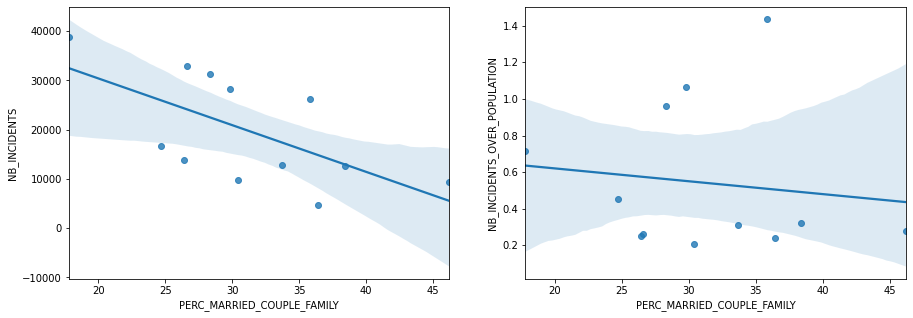

**We analyse if migration impact the incidents numbers and ratio**  
Number of incidents on the left Ratio of incident over total population on the right  
*Note the blue cone showing the interval confidence which is very wide, so difficult to draw conclusions*

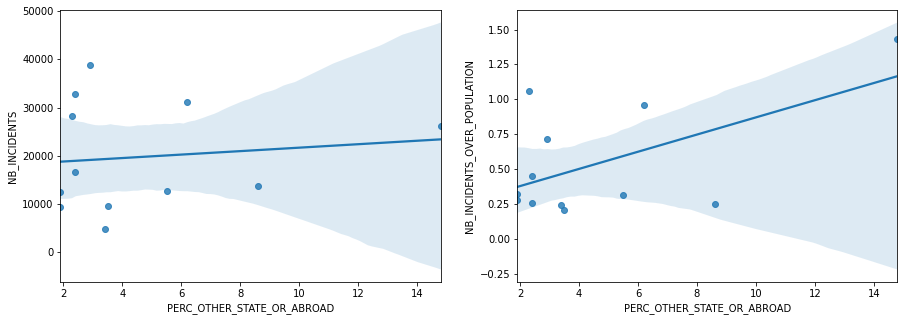

**At first sight in the numbers, it seems that the has not so much impact on number of incidents, , but actually looking at the ratio over total population it seems that there is a positive correlation driven mainly by Downtown district**

# Impact of distance with Police station ?

**We analyse if the average distance from the police station to area of incidents impact the incidents numbers and ratio**  
Number of incidents on the left Ratio of incident over total population on the right  
*Note the blue cone showing the interval confidence which is very wide, so difficult to draw conclusions*

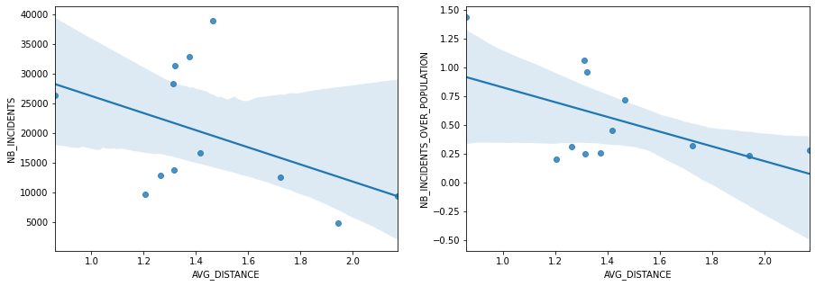

**At first sight it seems that the longer the distance, the lower number and ratio of incidents!**  
But what we are probably seeing is that the distances are correlated with historical number of incidents, meaning that police offices have a tendency to get closer over time to area with higher number of incidents